# **Modelación estadística en R para variables ambientales**

M.Sc. Esteban Ballestero Alfaro

[figure not shown]

# Exploración de datos

Una de las buenas prácticas que se recomienda implementar a la hora de analizar datos, es iniciar haciendo una mirada a estos de manera que desde el inicio, se pueda tener un visión general de la materia prima con la que se pretende trabajar.

## ¿Qué interesa conocer de los datos?

Cada analista podría definir sus propias prioridades, pero posiblemente se pueda tener un consenso en lo siguiente: tipos de datos, las variables, datos atípicos, celdas vacías, tamaño de la base de datos, estructura general de la base de datos, entre otras.

En R podemos echar mano de varias herramientas exploratorias de consulta o de tipo gráficas, que rápidamente permiten tener ese panorama general.

# Una mirada a los datos

Primeramente creamos un primer chunk para cargar los paquetes o librerías de R requeridos para el trabajo con los datos:

```r
library(visdat) # Paquete con varias herramientas para visualizar datos
library(DataExplorer) #Para usar la función plot_missing
library(mosaicData) # Paquete que contiene bases de datos
library(ggplot2) # paquete graficador de alto desempeño
library(colorspace) # Paleta de colores
library(dplyr) #para usar funciones de ordenamiento, selección, agrupación
library(GGally)
library(tidyr) # para usar la función drop_na
library(correlation) # para calcular correlaciones
library(PerformanceAnalytics)
library(psych)
library(ggraph)
```

`R` posee algunas bases de datos de uso libre, de las cuáles en esta oportunidad se cargará la base de datos *airquality* la cuál contiene datos ambientales.

En `RStudio` podemos consultar la ayuda si se desea saber información sobre algún paquete, una función o alguna base de datos. La siguiente instrucción permite acceder a la ayuda para conocer cómo está cosntituida la base de datos *airquality*:

```r
?airquality
```

```
## starting httpd help server ... done
```

Seguidamente se carga la base de datos:

```r
data("airquality") #Base de datos con variables que estudian la calidad del aire
```

Se puede ver un resumen sobre como está constituida dicha base de datos con las siguientes indicaciones:

```r
head(airquality)
```

|  | Ozone | Solar.R | Wind | Temp | Month | Day |
| --- | --- | --- | --- | --- | --- | --- |
| 1 | 41 | 190 | 7.4 | 67 | 5 | 1 |
| 2 | 36 | 118 | 8.0 | 72 | 5 | 2 |
| 3 | 12 | 149 | 12.6 | 74 | 5 | 3 |
| 4 | 18 | 313 | 11.5 | 62 | 5 | 4 |
| 5 | NA | NA | 14.3 | 56 | 5 | 5 |
| 6 | 28 | NA | 14.9 | 66 | 5 | 6 |

```r
summary(airquality)
```

```
##      Ozone           Solar.R           Wind             Temp
##  Min.   :  1.00   Min.   :  7.0   Min.   : 1.700   Min.   :56.00
##  1st Qu.: 18.00   1st Qu.:115.8   1st Qu.: 7.400   1st Qu.:72.00
##  Median : 31.50   Median :205.0   Median : 9.700   Median :79.00
##  Mean   : 42.13   Mean   :185.9   Mean   : 9.958   Mean   :77.88
##  3rd Qu.: 63.25   3rd Qu.:258.8   3rd Qu.:11.500   3rd Qu.:85.00
##  Max.   :168.00   Max.   :334.0   Max.   :20.700   Max.   :97.00
##  NA's   :37       NA's   :7
##      Month            Day
##  Min.   :5.000   Min.   : 1.0
##  1st Qu.:6.000   1st Qu.: 8.0
##  Median :7.000   Median :16.0
##  Mean   :6.993   Mean   :15.8
##  3rd Qu.:8.000   3rd Qu.:23.0
##  Max.   :9.000   Max.   :31.0
##
```

```r
str(airquality)
```

```
## 'data.frame':    153 obs. of  6 variables:
##  $ Ozone  : int  41 36 12 18 NA 28 23 19 8 NA ...
##  $ Solar.R: int  190 118 149 313 NA NA 299 99 19 194 ...
##  $ Wind   : num  7.4 8 12.6 11.5 14.3 14.9 8.6 13.8 20.1 8.6 ...
##  $ Temp   : int  67 72 74 62 56 66 65 59 61 69 ...
##  $ Month  : int  5 5 5 5 5 5 5 5 5 5 ...
##  $ Day    : int  1 2 3 4 5 6 7 8 9 10 ...
```

Usando el paquete visdat, hacemos una exploración gráfica de la base de datos:

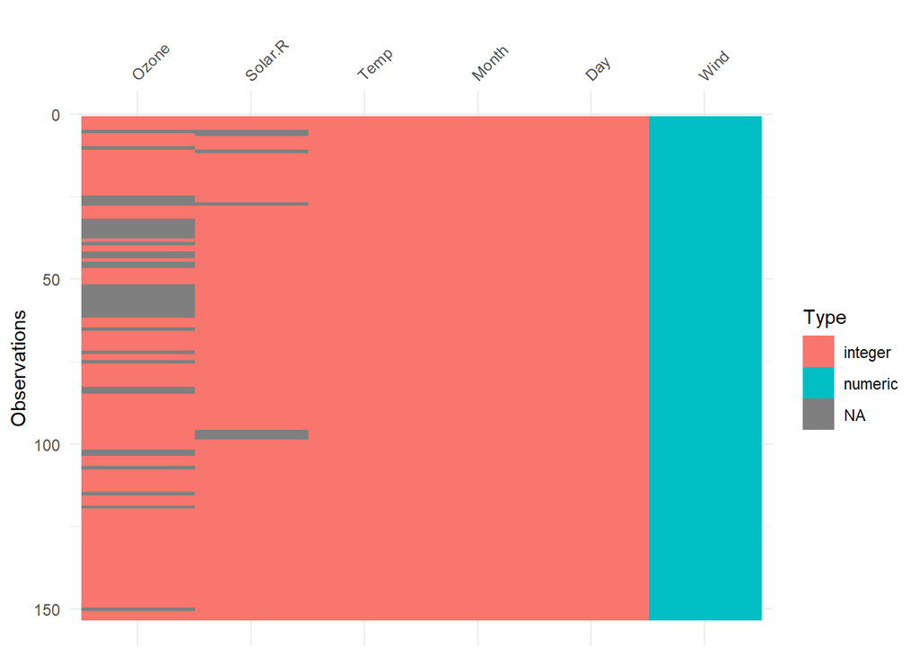

```r
vis_dat(airquality)
```

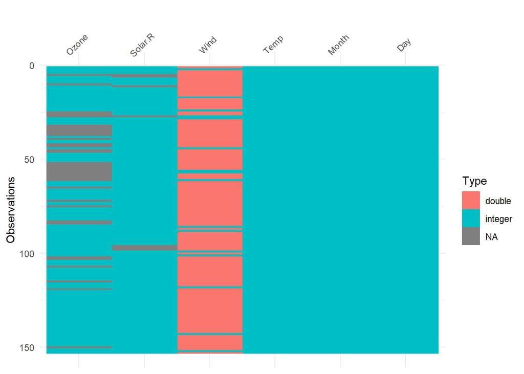

```r
vis_guess(airquality)
```

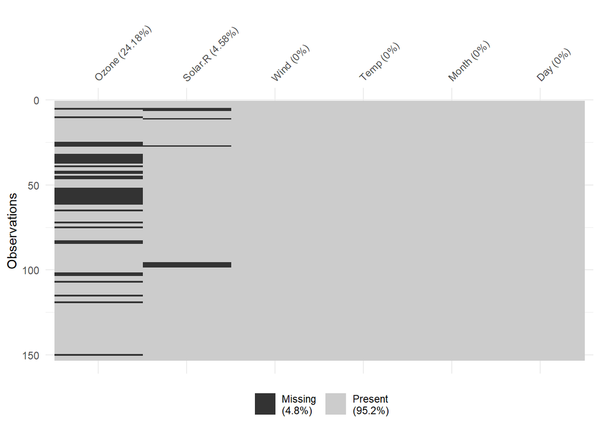

```r
vis_miss(airquality)
```

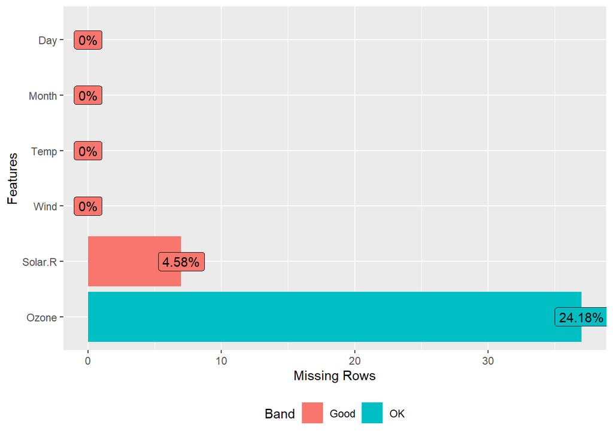

```r
plot_missing(airquality) # Me indica si tenemos datos en blanco y me da una recomendación, que en este caso dice que es "Good y Ok", lo cual no es mucho problema
```

```r
# Use ?plot_missing() si desea conocer más sobre esta función
```

Si se desea, se pueden omitir los datos NA, pero al implicar este procedimiento una modificación de la base de datos original, se recomienda crear una nueva variable de almacenamiento, como se muestra en el siguiente `chunk`:

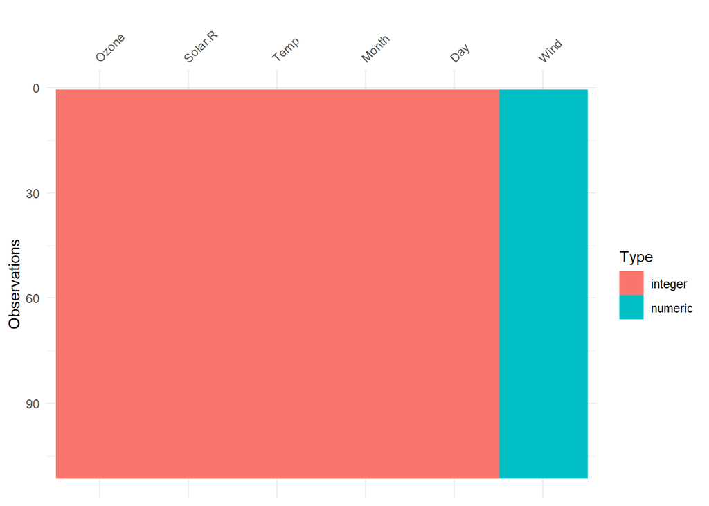

```r
aire <- na.omit(airquality)
vis_dat(aire)
```

# Atipicidades

Para el estudio de las tipicidades, se echará mano de dos tipos de gráficos del paquete ggplot2: *Diagramas de caja* (**boxplot**) y *gráficos de violín* (**Violinplot**).

El paquete `ggplot2` es uno de los paquetes más completos que tiene R para generar gráficos diversos y de alta complejidad y calidad, el cuál trabaja bajo una filosofía de *Grammar of Graphs (Gramática de gráficos)* que permite contruir los gráficos a partir de capas.

Primeramente se crea el marco de trabajo base (Primera capa), el cuál al contener solo la base de datos cargada, no mostrará ningún elemento visual:

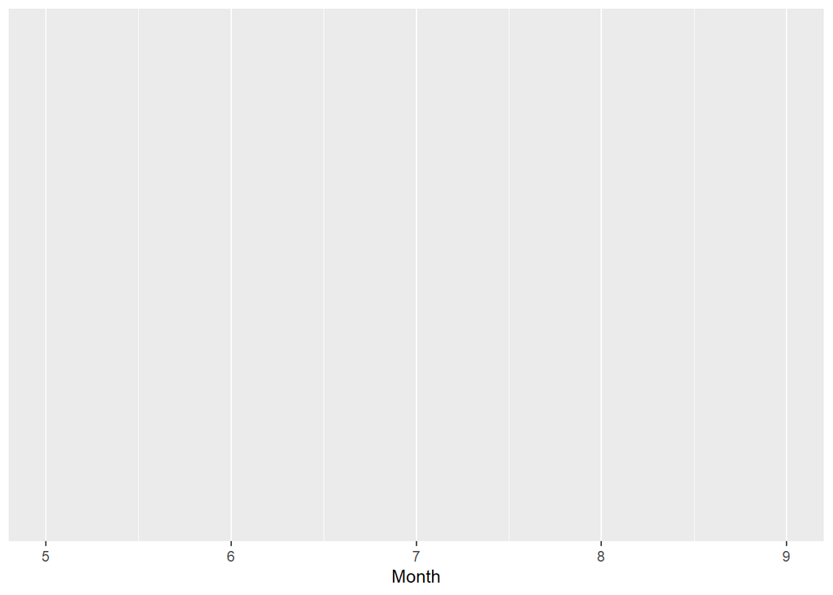

```r
ggplot(aire, aes(Month))
```

Ahora, se agrega una segunda capa de tipo `geom_boxplot`

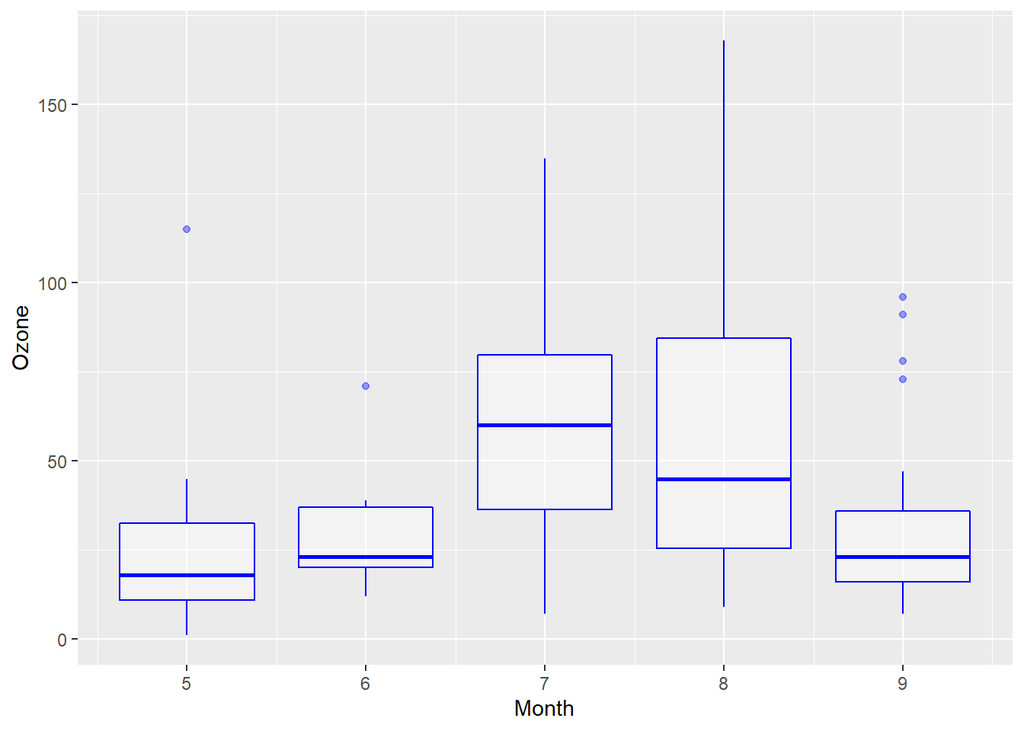

```r
ggplot(aire, aes(Month,Ozone )) +
  geom_boxplot(alpha = 0.4, color = "blue", aes(group = cut_width(Month, 1)))
```

En el gráfico anterior se puede notar que en el horizontal aparecen los meses dados por número de mes, pero podría ser interesante verlo con nombre del mes. El siguiente código crea una nueva columna en la base de datos con el nombre del mes

```r
aire$Mes <- ifelse(aire$Month == 5, "Mayo",
                   ifelse (aire$Month == 6, "Junio",
                           ifelse(aire$Month == 7,"Julio",
                                  ifelse(aire$Month == 8, "Agosto","Septiembre")
                                  )
                           )
                   )

aire$Mes <- factor(aire$Mes, levels = c("Mayo","Junio","Julio","Agosto","Septiembre"))
```

Seguidamente crearemos el mismo diagrama de caja, pero usando la nueva columnna

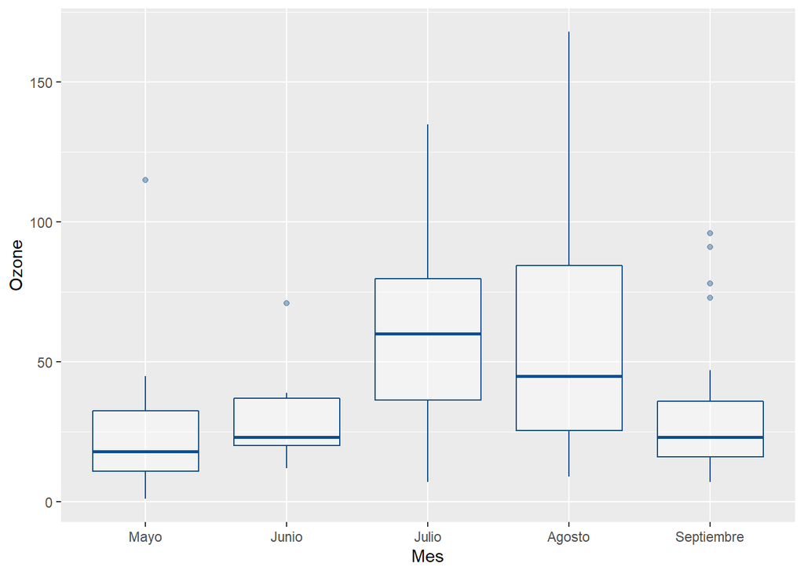

```r
ggplot(aire, aes(Mes, Ozone)) +
  geom_boxplot(alpha = 0.4, color = "dodgerblue4", outlier.shape = 19)
```

Los datos atípicos se muestran como puntos fuera de la caja, pero esa forma podría cambiar a gusto del usuario. En el siguiente enlace puede ver un compendio de variantes para la figura que podría usarse para representar los puntos en `R`

[Figuras para puntos ggplot2](https://ggplot2.tidyverse.org/articles/ggplot2-specs.html)

La siguiente variante del diagrama de caja puede ser más interesante:

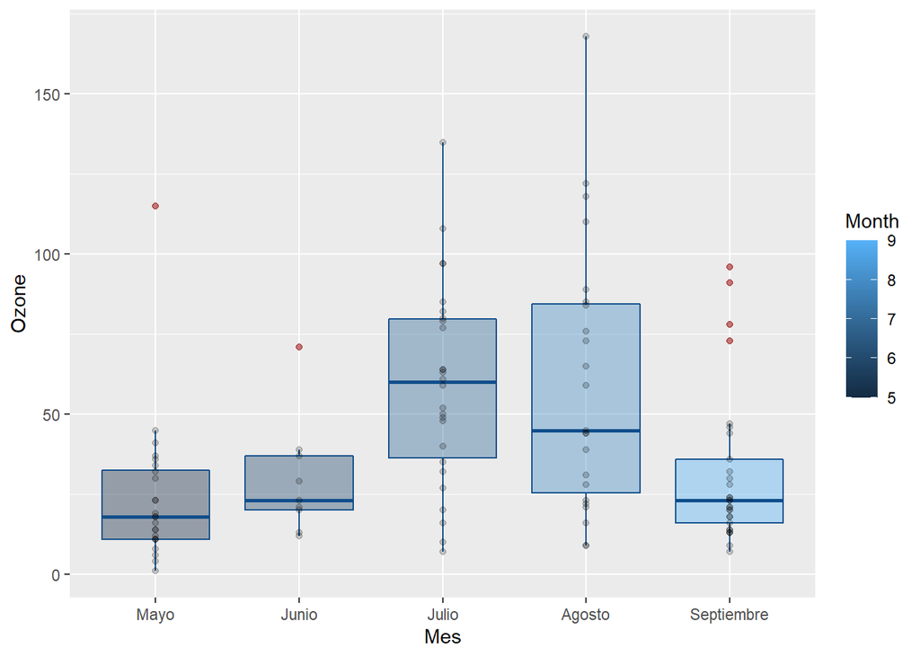

```r
ggplot(aire, aes(Mes, Ozone)) +
  geom_boxplot(alpha = 0.4, color = "dodgerblue4", outlier.shape = 19, outlier.color = "red", aes(fill = Month)) +
  geom_point(alpha = 0.2)
```

Agreguemos otros elementos importantes en un gráfico, como título:

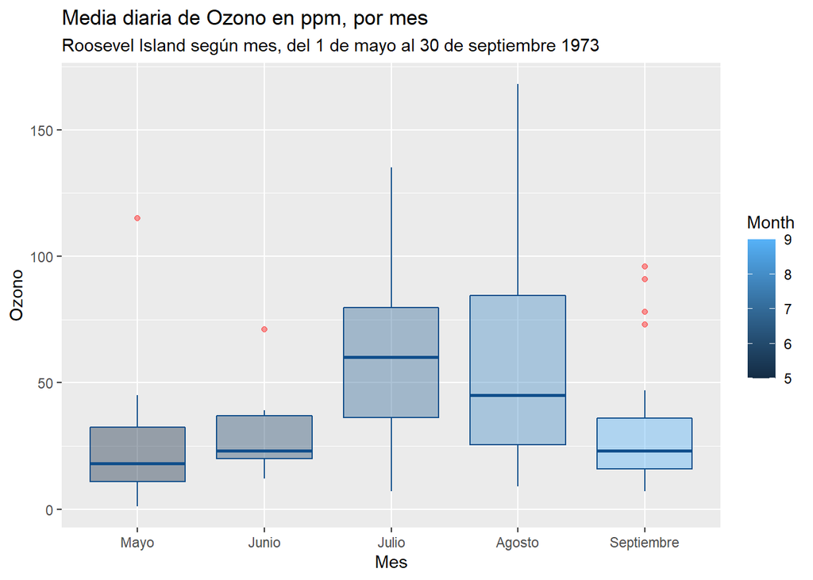

```r
ggplot(aire, aes(Mes, Ozone)) +
  geom_boxplot(alpha = 0.4, color = "dodgerblue4", outlier.shape = 19, outlier.color = "red", aes(fill = Month))+
  labs(title = "Media diaria de Ozono en ppm, por mes", subtitle = "Roosevel Island según mes, del 1 de mayo al 30 de septiembre 1973", y = "Ozono")
```

Otra variante interesante del diagrama de caja que se viene utilizando, es el *gráfico de violín* o *violin plot*, el cuál presenta la ventaja de que permite conocer la distribución de los datos durante el recorrido.

Antes de constuir nuestro primer *violin plot*, podemos simplificar el código almacenando instrucciones de uso frecuente, como seguidamente se muestra:

```r
# g1 es una variables que almacena la primera capa del gráfico a crear

g1 <- ggplot(aire, aes(Mes, Ozone))
```

Los *violinplot* son un tipo de función de densidad (density plot) para los datos vistos desde arriba.este gráfico se está prefiriendo sobre el *box plot*, porque permite ver en el recorrido la forma en que se agrupan o se concentran los datos. No es necesario, para efectos de publicación, presentarlo junto con la caja.

Seguidamente, se construye el *violin plot*:

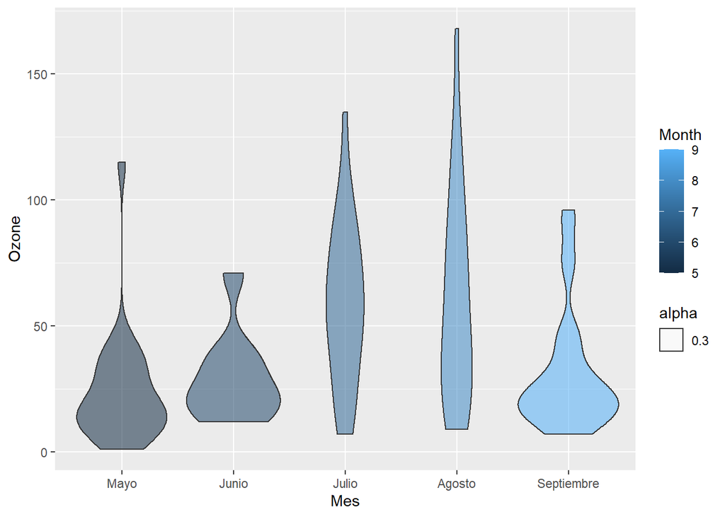

```r
g1 +
  geom_violin(aes(fill = Month, alpha = 0.3))
```

Se puede agregar los puntos para verlos superpuestos al violinplot:

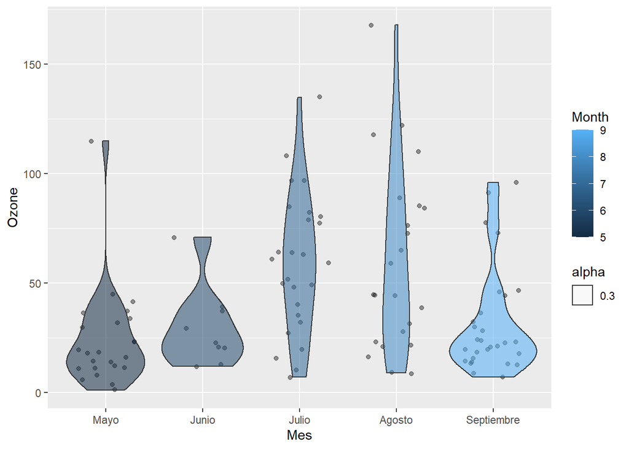

```r
g1 +
  geom_jitter(width = 0.3, alpha = 0.4) +
    geom_violin(aes(fill = Month, alpha = 0.3))
```

Se puede superponer además con los *box plot*:

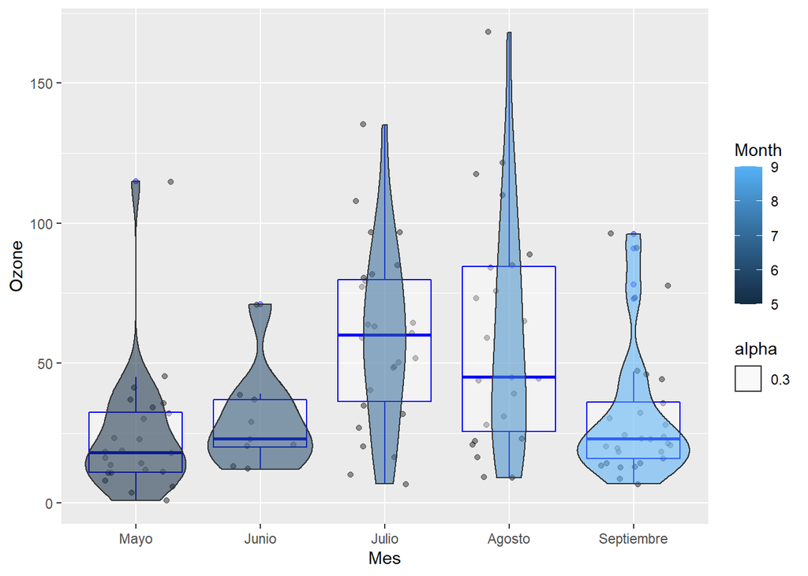

```r
g1 +
  geom_jitter(width = 0.3, alpha = 0.4) +
  geom_boxplot(alpha = 0.4, color = "blue") +
  geom_violin(aes(alpha = 0.3, fill = Month))
```

En el siguiente código se propone crear algunas estadísticas para los datos agrupados: cantidad de datos, desviación estándar, error estándar y lo límites superior e inferior para el intervalo de confianza para dicha media, con el objetico de incluirlos dentro del gráfico que se viene trabajando.

Para este trabajo se utilizará el operador *pipe* **%>%** que permite crear acciones anidadas:

```r
est <- aire %>%
  group_by(Mes) %>%
  summarise(media = mean(Ozone),
            n = n(),
            de = sd(Ozone),
            ee = de/sqrt(n()),
            li = media - 1.96*ee,
            ls = media +1.96*ee
            )
est
```

| Mes | media | n | de | ee | li | ls |
| --- | --- | --- | --- | --- | --- | --- |
| Mayo | 24.12500 | 24 | 22.88594 | 4.671573 | 14.96872 | 33.28128 |
| Junio | 29.44444 | 9 | 18.20790 | 6.069301 | 17.54861 | 41.34028 |
| Julio | 59.11538 | 26 | 31.63584 | 6.204298 | 46.95496 | 71.27581 |
| Agosto | 60.00000 | 23 | 41.76776 | 8.709179 | 42.93001 | 77.06999 |
| Septiembre | 31.44828 | 29 | 24.14182 | 4.483024 | 22.66155 | 40.23500 |

Se procede a incluir estas nuevas estadísticas al gráfico:

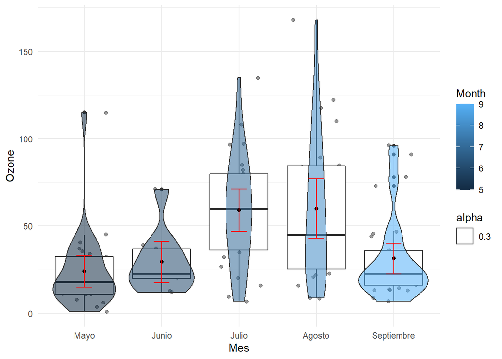

```r
g1 +
  geom_jitter(width = 0.3, alpha = 0.4) +
  geom_boxplot() +
  geom_violin(aes(alpha = 0.3, fill = Month)) +
  theme_minimal() +
  geom_point(data = est, aes(Mes, media)) +
  geom_errorbar(data = est, aes(Mes, media, ymin = li, ymax = ls), width = 0.2, color ="red")
```

Los *gráficos* de barras y una variante conocida como *lollipops* podrín ser útiles en el conteo de datos:

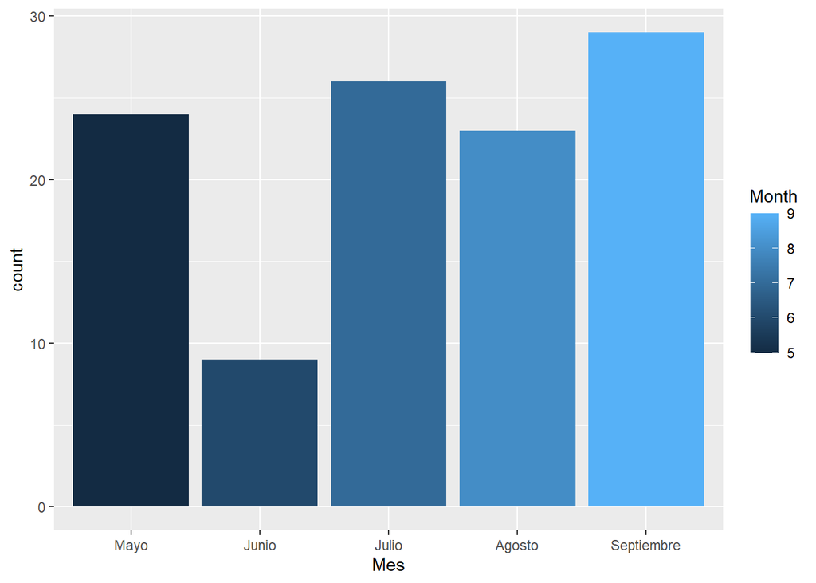

```r
ggplot(aire, aes(Mes)) +
  geom_bar(aes(fill = Month))
```

```r
mescont <- aire %>%
  group_by(Mes) %>%
  summarize(conteo = n() )
```

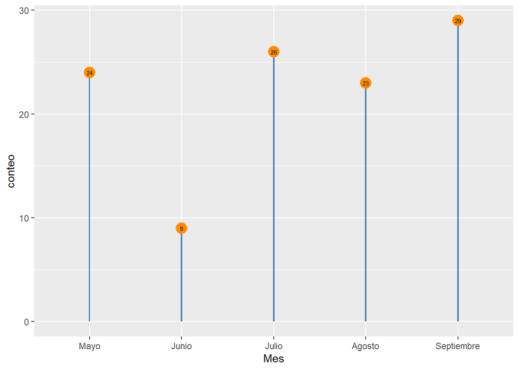

```r
ggplot(mescont, aes(Mes, conteo)) +
  geom_col(fill = "steelblue", width = 0.015) +
  geom_point(color = "darkorange", size = 5) +
  geom_text(aes(label = conteo), size = 2)
```

# Una mirada a las correlaciones

`R` permite constuir matrices gráficas con información variada de los datos, como por ejemplo los gráficos de densidad, gráfico de dispersión y correlaciones que facilitan ese acercamiento a la base de datos a trabajar.

Este gráfico se construye con el paquete GGally:

ggpairs(datos[filas, c(“Columna 1”, “Columna2”,…, “Columna n”)])

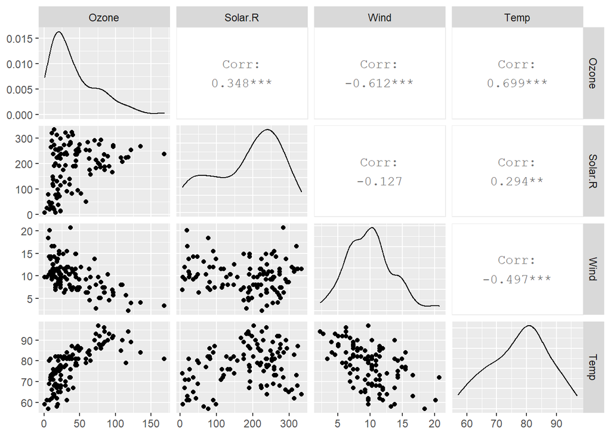

```r
ggpairs(aire[, c("Ozone", "Solar.R","Wind", "Temp")])
```

Veamos otras opciones de matrices de gráficos de resumen de datos usando los paquetes `peformanceanalitycs` y `psych`:

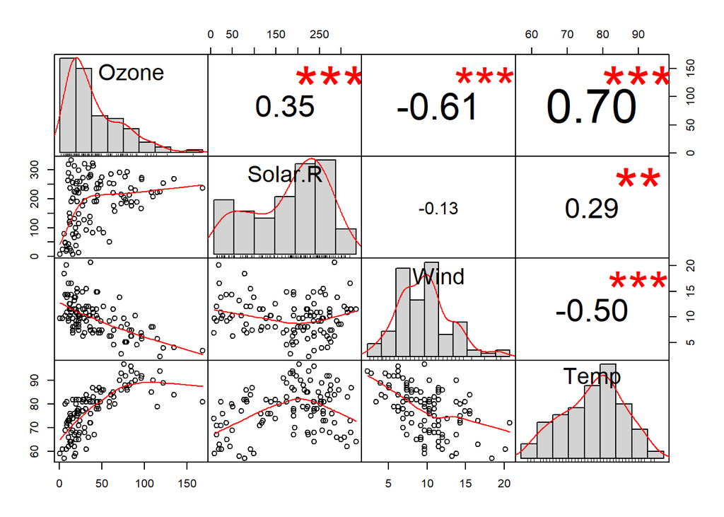

```r
chart.Correlation(aire[, c("Ozone", "Solar.R","Wind", "Temp")], histogram=TRUE, pch=19)
```

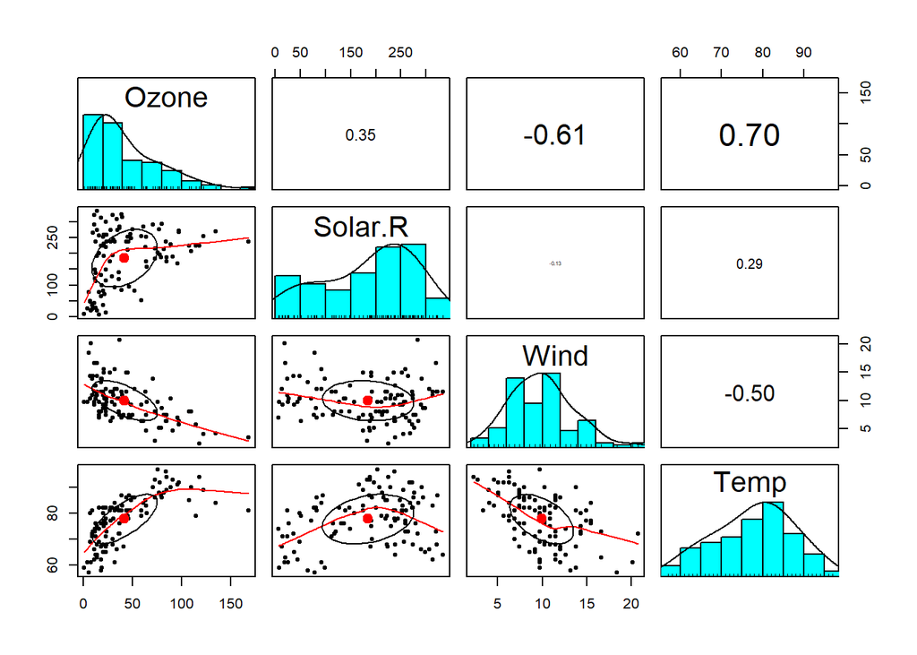

```r
pairs.panels(aire[, c("Ozone", "Solar.R","Wind", "Temp")], scale=TRUE)
```

Seguidamente se hace un análisis para las correlaciones, la idea es ver si entre las variables numéricas presentes existe algún tipo de correlación fuerte.

Primeramente, trabajaremos con la base de datos original, es decir, sin la nueva columna creada para el Mes:

```r
calidadaire <- na.omit(airquality)
head(calidadaire)
```

|  | Ozone | Solar.R | Wind | Temp | Month | Day |
| --- | --- | --- | --- | --- | --- | --- |
| 1 | 41 | 190 | 7.4 | 67 | 5 | 1 |
| 2 | 36 | 118 | 8.0 | 72 | 5 | 2 |
| 3 | 12 | 149 | 12.6 | 74 | 5 | 3 |
| 4 | 18 | 313 | 11.5 | 62 | 5 | 4 |
| 7 | 23 | 299 | 8.6 | 65 | 5 | 7 |
| 8 | 19 | 99 | 13.8 | 59 | 5 | 8 |

Podemos usar el operador *pipe* para filtar nuestra base de datos, como se muestra acontinuación:

```r
calidadaire <- airquality %>% # se indica cuál es la base de datos usada
  drop_na() %>% # se eliminan los na, toda la fila
  dplyr::select(-c(Month, Day)) # eliminamos las columnas Month y Day
```

Es impornte explicar el significado de la instrucción dplyr::select.

Ocurre con frecuencia en `R` que muchos paquetes podrían tener una función con el mismo nombre, entonces, cuando se llama a la función, que en este ejemplo es **select**, y queremos que sea **select** del paquete `dplyr` específicamente y no de otro paquete, entonces se debe indicar el nombre del paquete seguido por el operardor **::** y luego la función a usar.

Note que los datos ya no contienen las celdas vacías ni tampoco las columnas de *Month* y *Day*.

Es importante tomar en cuenta que la correlación lineal es una métrica sobre la relación lineal entre dos variables, no es un modelo como si lo es una regresión lineal.

Hay varias formas de ver las correlaciones en `R`, seguidamente se presentan varias opciones:

```r
cor <- correlation(calidadaire)
cor
```

|  | Parameter1 | Parameter2 | r | CI_low | CI_high | t | df | p | Method | n_Obs |
| --- | --- | --- | --- | --- | --- | --- | --- | --- | --- | --- |
| 1 | Ozone | Solar.R | 0.3483417 | 0.1731940 | 0.50213196 | 3.879795 | 109 | 5.379326e-04 | Pearson | 111 |
| 2 | Ozone | Wind | -0.6124966 | -0.7170298 | -0.48101924 | -8.089650 | 109 | 4.544708e-12 | Pearson | 111 |
| 3 | Ozone | Temp | 0.6985414 | 0.5888139 | 0.78298694 | 10.191861 | 109 | 9.316063e-17 | Pearson | 111 |
| 4 | Solar.R | Wind | -0.1271835 | -0.3063148 | 0.06064716 | -1.338706 | 109 | 1.834520e-01 | Pearson | 111 |
| 5 | Solar.R | Temp | 0.2940876 | 0.1139405 | 0.45551131 | 3.212423 | 109 | 3.461571e-03 | Pearson | 111 |
| 6 | Wind | Temp | -0.4971897 | -0.6256061 | -0.34254099 | -5.982668 | 109 | 1.136786e-07 | Pearson | 111 |

Podríamos resumir esta tabla:

```r
summary(cor)
```

|  | Parameter | Temp | Wind | Solar.R |
| --- | --- | --- | --- | --- |
| 1 | Ozone | 0.6985414 | -0.6124966 | 0.3483417 |
| 2 | Solar.R | 0.2940876 | -0.1271835 | NA |
| 3 | Wind | -0.4971897 | NA | NA |

Graficar los datos de la matriz resultante de la correlación es posible, pero primero se debe organizar la infomración para que la función *plot* puede interpretarlos correctamente. Note que el resultado anterior del *summary* muestra una matriz triangular, pero el comando *plot* necesita que esta matriz sea cuadrada para poder graficar correctamente.

La siguiente instrucción, permite hacer cuadrada la matriz de correlaciones:

```r
summary(cor, redundant = T)
```

|  | Parameter | Ozone | Solar.R | Wind | Temp |
| --- | --- | --- | --- | --- | --- |
| 1 | Ozone | 1.0000000 | 0.3483417 | -0.6124966 | 0.6985414 |
| 2 | Solar.R | 0.3483417 | 1.0000000 | -0.1271835 | 0.2940876 |
| 3 | Wind | -0.6124966 | -0.1271835 | 1.0000000 | -0.4971897 |
| 4 | Temp | 0.6985414 | 0.2940876 | -0.4971897 | 1.0000000 |

Se podría graficar de la siguiente manera:

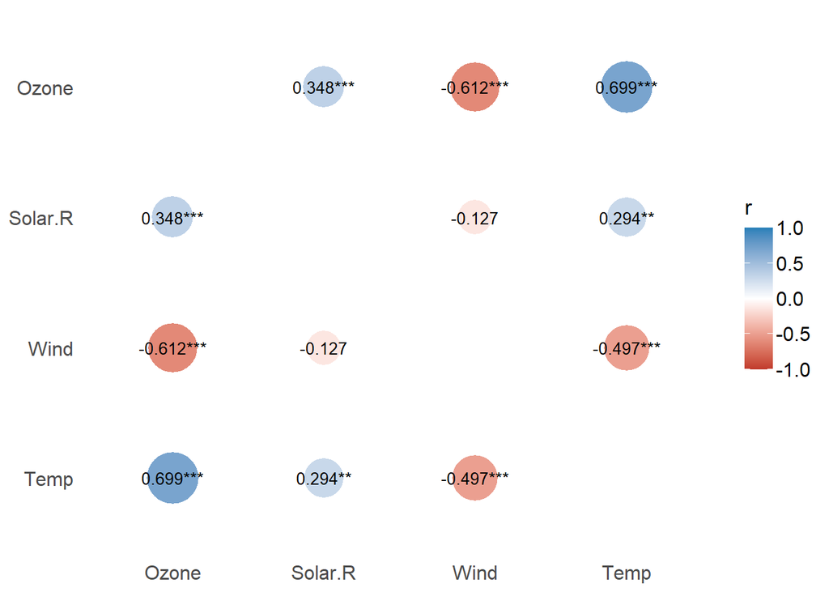

```r
plot(summary(cor, redundant = T), show_value = T, show_p = T)
```

Una forma más elegante de hacer este gráfico, es a partir del operador *pipe*:

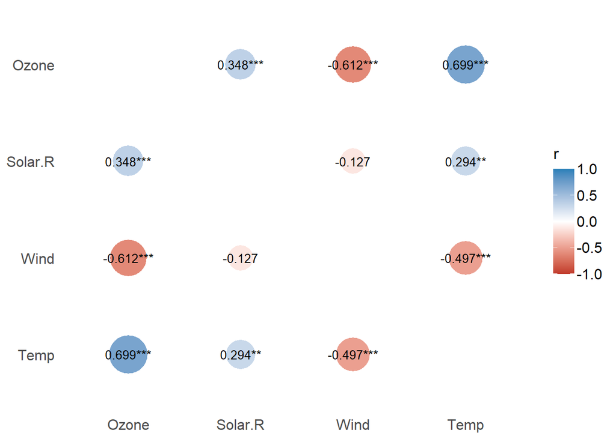

```r
cor %>%
  summary(redundant =TRUE) %>%
  plot(show_value = T, show_p  = T)
```

Se puede cambiar la forma de la geometría:

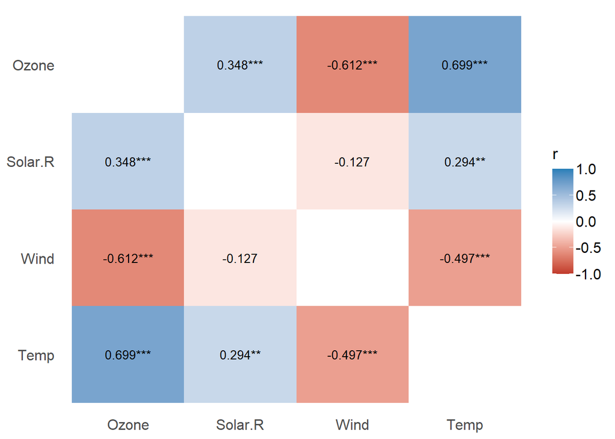

```r
cor %>%
  summary(redundant =TRUE) %>%
  plot(show_value = T, show_p  = T, type = "tile")
```

El siguiente gráfico de correlación se base en un modelo gaussiano, requiere el paquete `ggraph`

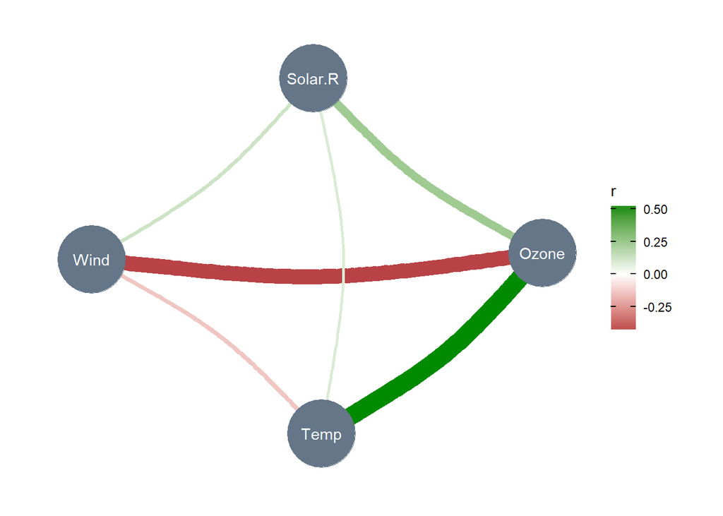

```r
calidadaire  %>%
  correlation(partial = TRUE) %>%
  plot()
```

# Bases para la regresión

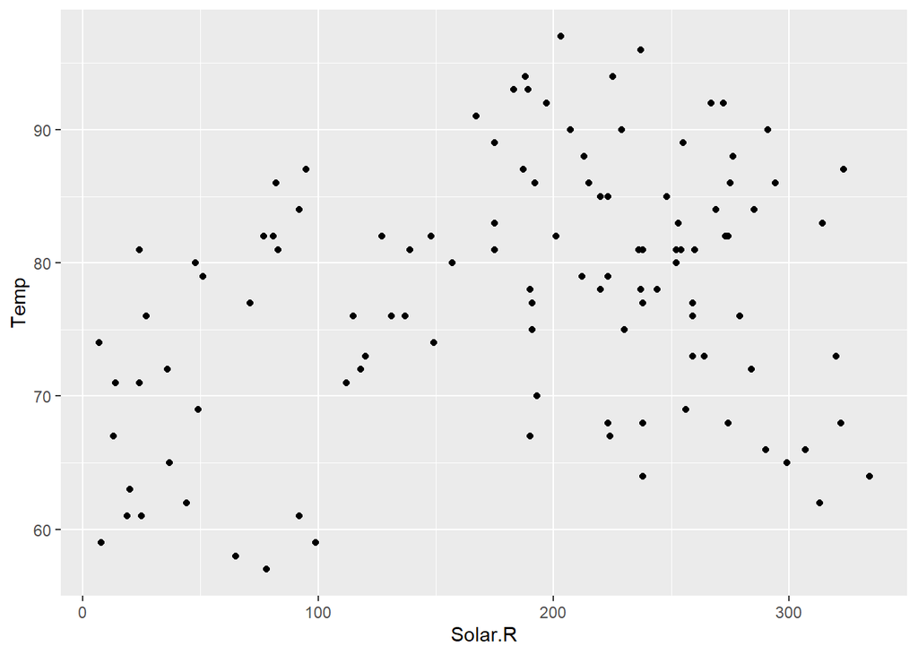

```r
ggplot(calidadaire, aes(Solar.R, Temp)) +
  geom_point()
```

Con la capa stat_smooth se puede trazar una curva de mejor ajuste para los datos

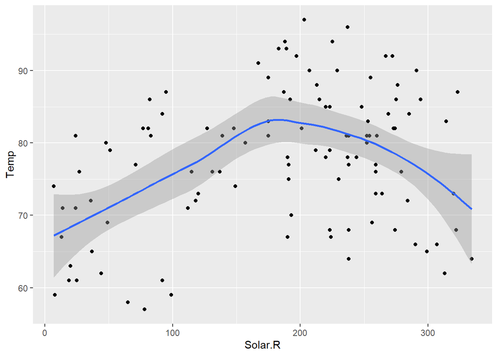

```r
ggplot(calidadaire, aes(Solar.R, Temp)) +
  geom_point() +
  stat_smooth()
```

Esta opción de smooth es una ayuda al ojo para encontrar patrones en los datos.

Se puede usar el método lm para comparar entre el partrón anterior y como se vería una ajuste lineal:

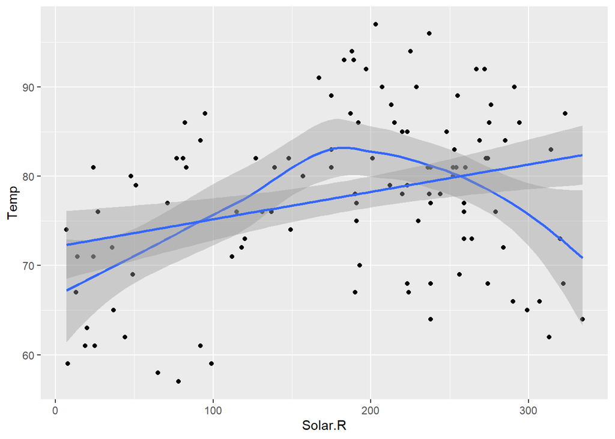

```r
ggplot(calidadaire, aes(Solar.R, Temp)) +
  geom_point() +
  geom_smooth() +
  geom_smooth(method = "lm")
```

Similarmente, comparemos las variables Solar.R y Wind:

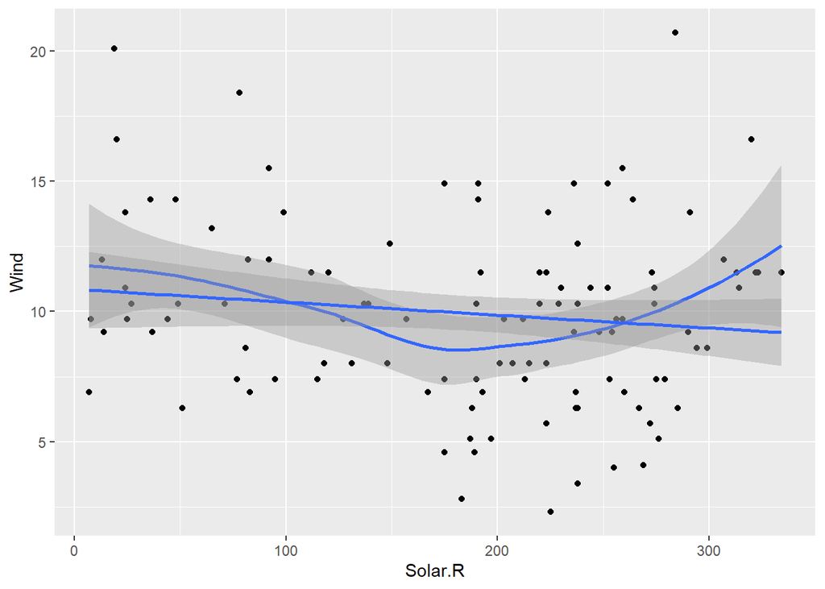

```r
ggplot(calidadaire, aes(Solar.R, Wind)) +
  geom_point() +
  geom_smooth() +
  geom_smooth(method = "lm")
```

Otra forma de ver sl gráfico:

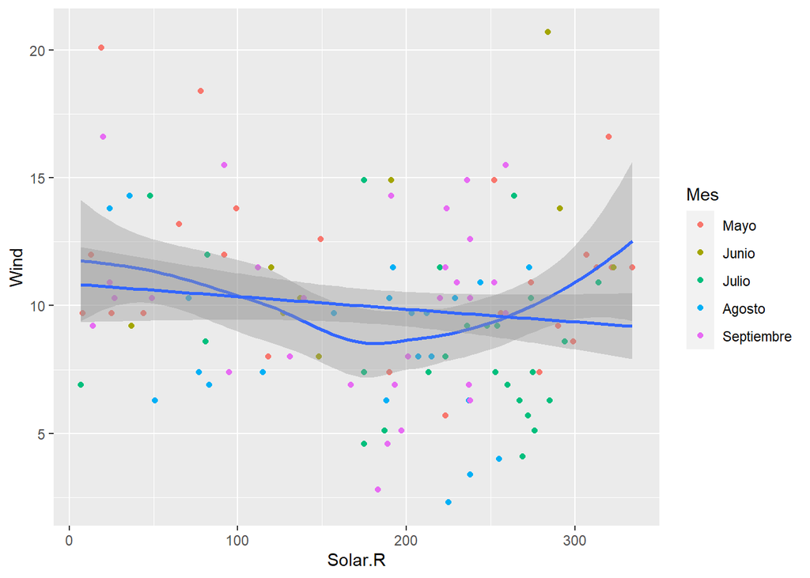

```r
ggplot(aire, aes(Solar.R, Wind)) +
  geom_point(aes(color = Mes)) +
  geom_smooth() +
  geom_smooth(method = "lm")
```

Recordemos la correlación entre estas dos variables:

```r
cor_test(calidadaire, "Solar.R", "Wind")
```

| Parameter1 | Parameter2 | r | CI_low | CI_high | t | df | p | Method | n_Obs |
| --- | --- | --- | --- | --- | --- | --- | --- | --- | --- |
| Solar.R | Wind | -0.1271835 | -0.3063148 | 0.06064716 | -1.338706 | 109 | 0.183452 | Pearson | 111 |

Note que el IC contempla al valor cero, por lo que podría no haber correlación lineal.